# MTH6139 Time Series

### 2.2 Trend Analysis

This section aims to explore the general trend growth of *Atmospheric CO2 Concentration* in more detail by fitting a **Linear Model** with *Linear, Quadratic and Cubic Regression* to `co2` time series. The **Linear Model** is fit to the data using the built in `R` function `lm()`.

Due to how `R` is set up, `co2` will first need to be converted into a data frame. To do this we will use `data.frame` function with two arguments, **t** for time and **x** for the co2 observations.

```r
CO2_dataframe = data.frame(t = as.vector(time(co2)), x = as.vector(co2))
```

*Please Note:* after converting any data into a data frame it is highly recommended to check the first couple of rows and the structure of the data frame. This can be done by running the following commands `head(CO2_dataframe)` and `str(CO2_dataframe)`.

The data is now ready for **Regression Testing**.

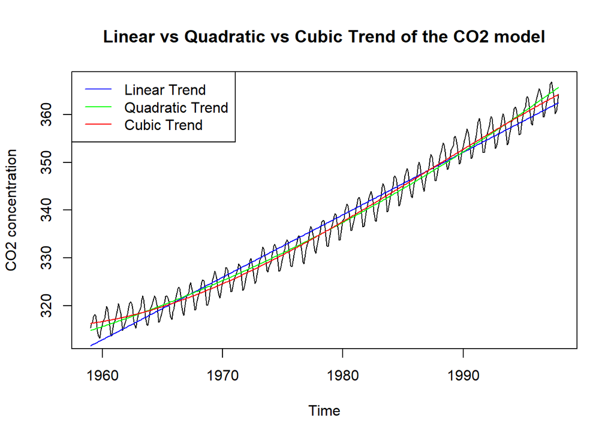

```r
# Plot the data frame:
plot(CO2_dataframe$t, CO2_dataframe$x, ylab = "CO2 concentration", xlab = "Time", main = "Linear vs Quadratic vs Cubic Trend of the CO2 model",type = 'l')
# Plot Linear Regression:
CO2_linear_model = lm(x~t, CO2_dataframe)
lines(CO2_dataframe$t, fitted(CO2_linear_model), type = 'l', col = 'blue')

# Plot Quadratic Regression:
CO2_quadratic_model = lm(x~t+I(t^2), CO2_dataframe)
lines(CO2_dataframe$t, fitted(CO2_quadratic_model), type = 'l', col = 'green')

# Plot Cubic Regression:
CO2_cubic_model = lm(x~t+I(t^2)+I(t^3), CO2_dataframe)
lines(CO2_dataframe$t, fitted(CO2_cubic_model), type = 'l', col = 'red')

# Adding a legend:
legend("topleft", legend = c("Linear Trend", "Quadratic Trend", "Cubic Trend"), col = c("blue", "green", "red"), lty = 1)
```

Trend Analysis begins by first fitting a *Linear Trend Model* to the `co2` time series, and it is represented by the blue line. Upon inspection it is clear that the initial assumption that `co2` data follows a strong linear trend proved to be incorrect, as the fitted line clearly doesn’t fit the data in the ideal way.

Next the *Quadratic Trend Model* was fit to the `co2` time series, represented by the green line. Clearly, this is a significant improvement as the fitted line passes almost through the center of each point. This is a clear improvement to the *Linear Trend Model*.

Lastly, the *Cubic Trend Model* was fit to the time series, represented by the red line in the diagram. It is clear that *Cubic Trend Model* fits the data the best out of the three models as the fitted line passes ideally through the center of each point.

To further confirm the above statement we will look at the *R-square* value of each model. This can be done by running the `summary()` command on each model. `summary()` function is used to produce a summary of the results of the fitted models.

```r
# Summary of the Linear Trend Model:
summary(CO2_linear_model)

# Summary of the Quadratic Trend Model:
summary(CO2_quadratic_model)

# Summary of the Cubic Trend Model:
summary(CO2_cubic_model)
```

[output not shown]

**R-squared** measures the goodness of fit of a regression model. Therefore, the model with the highest **R-squared** value should be selected.

We will now take a look at the coefficients of the *Cubic Trend Model* to determine the average increase in the *Atmospheric CO2 Concentration*.

```r
CO2_cubic_model$coefficients
```

```
##   (Intercept)             t        I(t^2)        I(t^3)
##  3.931077e+06 -5.937905e+03  2.989235e+00 -5.014803e-04
```

## 3. Testing for Heteroscedasticity

**Heteroscedasticity** refers to situations where the variance of a data set changes over time - variance is dependent on time.

The time series needs to be **stationary**, particularly **homoskedastic**. This means that time series need to follow the assumption of constant mean and variance.

### 3.1 Breusch-Pagan Test

The **Breusch-Pagan** test is often used to test for heteroscedasticity in regression models. **Breusch-Pagan** test works by fitting a linear regression model to the residuals of a linear regression model. In this case, **Breusch-Pagan** test will be evaluating the residuals of a **Cubic Trend Model** that was calculated in the previous section.

To perform this test in `R`, we will use the `pbtest` function available through the `lmtest` package. *(Please refer to Section 1.2 for instructions on how to install the package.)*

*Hypothesis Test:*

- **Null Hypothesis:** model meets the **homoskedastic** assumption - mean and variance are constant.
- **Alternative Hypothesis:** model displays evidence of heteroscedasticity in the residuals.
- Significance level = 0.05

```r
lmtest::bptest(CO2_cubic_model)
```

```
##
##  studentized Breusch-Pagan test
##
## data:  CO2_cubic_model
## BP = 9.9949, df = 3, p-value = 0.01861
```

From the output above it is clear that the p-value is less than the significance level (0.01861 < 0.05), hence the **Null Hypothesis** is rejected. This is a clear indication that `co2` time series does not meet the requirement of constant variance and mean, and therefore will need to be stabilized.

### 3.2 Variance Stabilisation with Box-Cox

**Box-Cox** is a technique that is frequently used to stabilise the variance. The **Box-Cox** works by transforming the data using the lambda parameter, optimal lambda value is chosen by performing maximum likelihood using the past data. Luckily, `R` will select the optimal lambda automatically.

To perform **Box-Cox transformation** we will use `BoxCox` unction available through the `forecast` package. *(Please refer to Section 1.2 for instructions on how to install the package.)*

```r
# Calculating the optimal lambda:
lambda = forecast::BoxCox.lambda(co2); lambda
```

```
## [1] -0.03432107
```

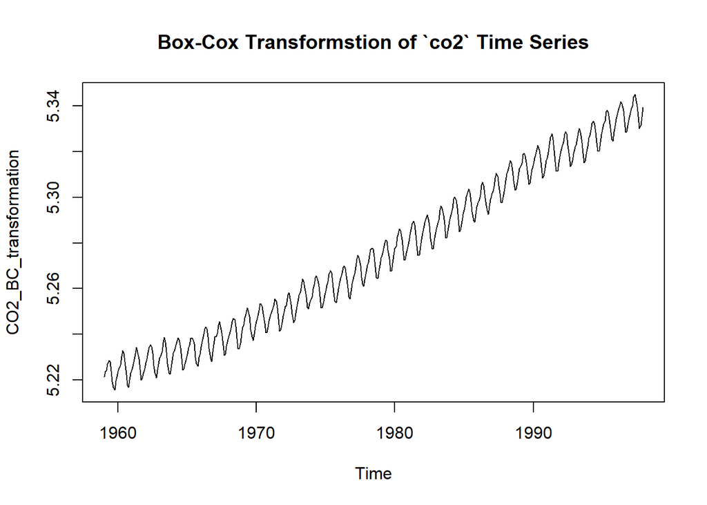

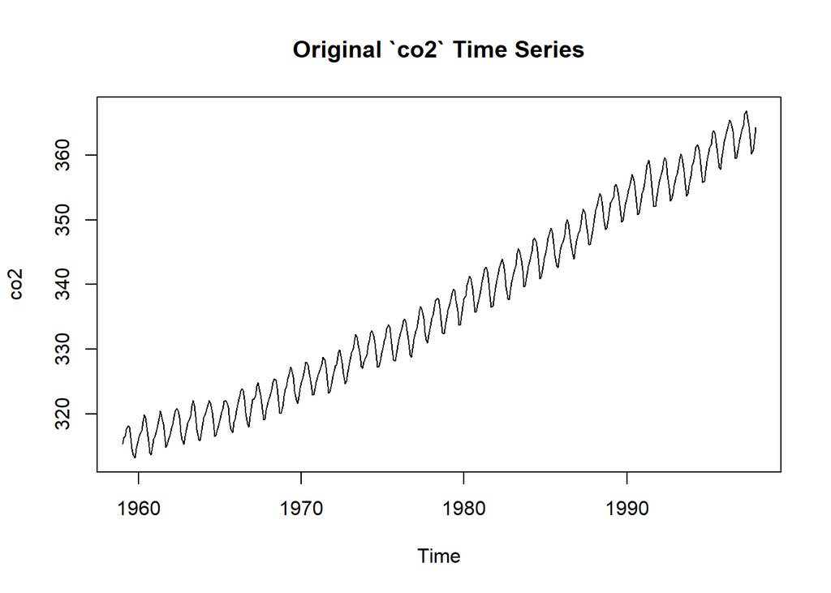

```r
# Box-Cox Transformation:
CO2_BC_transformation = forecast::BoxCox(co2, lambda)
plot(CO2_BC_transformation, main = "Box-Cox Transformstion of `co2` Time Series"); plot(co2, main = "Original `co2` Time Series")
```

- `BoxCox.lambda()` function has used maximum likelihood to find the optimal value of lambda. For `co2` the optimal lambda is -0.03432107.
- `BoxCox()` has preformed transformation of the original `co2` time series using the optimal lambda value,-0.03432107. By plotting the **Box-Cox** transformation we conclude that we have stabilised the variance of the time series

## 4. Analysis with Prophet.

This section aims to use the recorded data of *Atmospheric CO2 Concentration* located in the `co2` data set to make future predictions of increase in *Atmospheric CO2 Concentration* emitted by the **Mauna Loa Volcano**.

*The forecast will make predictions for the following time periods using the different frequencies:*

- 3 years ~ month
- 20 years ~ quarter

### 4.1 Setting Up the Initial Prophet Model

Before forecasting can be carried out we need to set up a *prophet model* that we will use to create future predictions. Luckily, its easy to do in a couple of steps.

1. First we will create a new data frame out of our `co2` time series. Like before this is done by running a `data.frame` function on the time series. The new data frame will consist of two variables:

ds - which will contain the time values from our time series.

Please note that here we are also running an additional function `zoo::as.yearmon`, which is used to represent monthly data. (Under newer versions of `R`, `zoo` is a built in package and does not need to be installed)

y - contains the observed data valuse from the time series `co2`.

2. Lastly, we set up the *prophet model* by running `prophet::prophet` function on the newly created data frame. *(Please note that `prophet` package will first need to be installed before this code can be used, refer to section 1.2 for more instructions )*

*Example:*

```r
# Creating a new data frame:
CO2_prophet_dataframe = data.frame(
  ds=zoo::as.yearmon(time(co2)),
  y=co2)
# Creating Prophet Model of `co2` data frame
prophet_model = prophet::prophet(CO2_prophet_dataframe)
```

### 4.2 Three Year Forecast

In this section we will perform a 3 Year forecast using monthly frequency. (3 years = 36 months).

```r
# Creating a new data frame:
CO2_prophet_dataframe = data.frame(
  ds=zoo::as.yearmon(time(co2)),
  y=co2)
# Creating Prophet Model of `co2` data frame
prophet_model = prophet::prophet(CO2_prophet_dataframe)
```

```
## Disabling weekly seasonality. Run prophet with weekly.seasonality=TRUE to override this.
```

```
## Disabling daily seasonality. Run prophet with daily.seasonality=TRUE to override this.
```

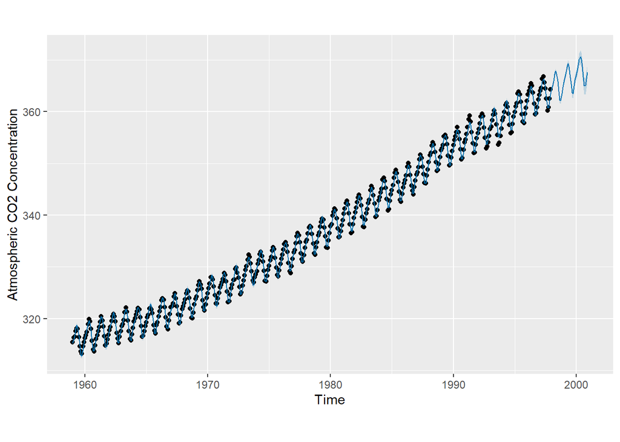

```r
# Creating a future data frame:
CO2_future_dataframe = prophet::make_future_dataframe(prophet_model, periods=36, freq="months")

# Predicting future co2 concentration:
CO2_Concentration_Forecast= predict(prophet_model, CO2_future_dataframe)
plot(prophet_model, CO2_Concentration_Forecast, ylabel = "Atmospheric CO2 Concentration", xlabel = "Time")
```

The graph above shows a three year forecast of Atmospheric CO2 Concentration produced by the Mauna Loa Volcano. Black dots on the graph represent the observed historic information of Atmospheric CO2 Concentration between 1959 and 1997. The thin blue line represents the fitted line between the observations, and represents the seasonal pattern that Atmospheric CO2 Concentration posses.

From the graph we can see that `prophet` has neatly forecasted the observations until about 2000’s. Until this point the thin blue follows the previous seasonal pattern well with little variation.

After 2000’s however, we can see a faint blue shaded area starting to appear around the the thin blue line, this shows the possible variations in the seasonal trend, it can either be larger than the fitted line or lower.

We will now take a look at the trend and the yearly components of the Atmospheric CO2 Concentration:

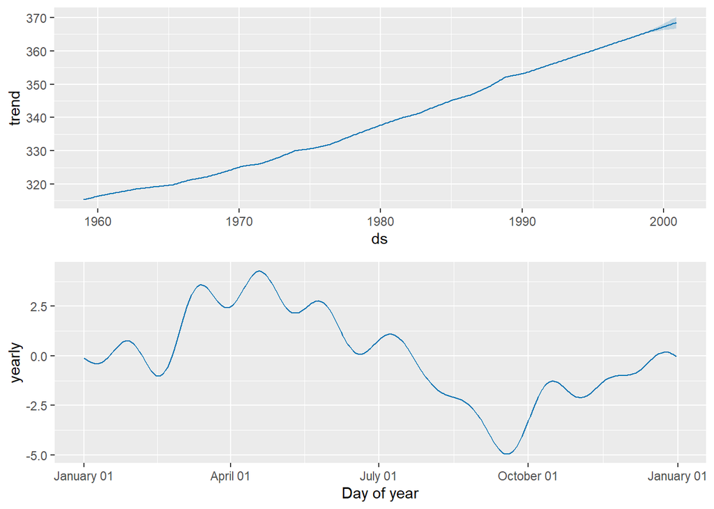

```r
prophet::prophet_plot_components(prophet_model, CO2_Concentration_Forecast)
```

The first graph represents the overall trend, like we have seen before Atmospheric CO2 Concentration has a positive growth trend. This means that average Atmospheric CO2 Concentration increases with time. The shaded region in light blue at the end of the trend line represents the potential deviation in the trend line, which means that it can either fall or increase that region. The deviation region is really small so it shouldn’t cause any problems.

The second graph represents the yearly component and it breaks down the Atmospheric CO2 Concentration by month. By visual inspection it can be seen that Atmospheric CO2 Concentration is the highest during the March-June period, so we can assume that the Volcano is the most active during this period.

After the month of July we can see a sharp decrease in the Atmospheric CO2 Concentration, which means that the volcano is becoming less active after its peak in mid April. Volcano is the least active during the month of September. After hitting its lowest point the volcano starts to become more active which is reflected by the increasing Atmospheric CO2 Concentration. Atmospheric CO2 Concentration will continue to increase until reaching its peak in mid April. Therefore this explains the seasonal trend we have seen in the previous sections.

By inspecting `CO2_Concentration_Forecast$yaht` we will obtain the estimated values that `prophet` has produced. The first entry represents Atmospheric CO2 Concentration on 01/01/1959 which was 315.2762. This is in contrast to the Atmospheric CO2 Concentration `prophet` has predicted on 2000-12-01 which is 367.5616. This further demonstrates that Atmospheric CO2 Concentration continues to increase over time.

### 4.3 Twenty Year Forecast

In this section we will perform a 20 Year forecast using quarterly frequency. (20 years = 80 quarters).

```r
# Creating a new data frame:
CO2_prophet_dataframe = data.frame(
  ds=zoo::as.yearmon(time(co2)),
  y=co2)
# Creating Prophet Model of `co2` data frame
prophet_model = prophet::prophet(CO2_prophet_dataframe)
```

```
## Disabling weekly seasonality. Run prophet with weekly.seasonality=TRUE to override this.
```

```
## Disabling daily seasonality. Run prophet with daily.seasonality=TRUE to override this.
```

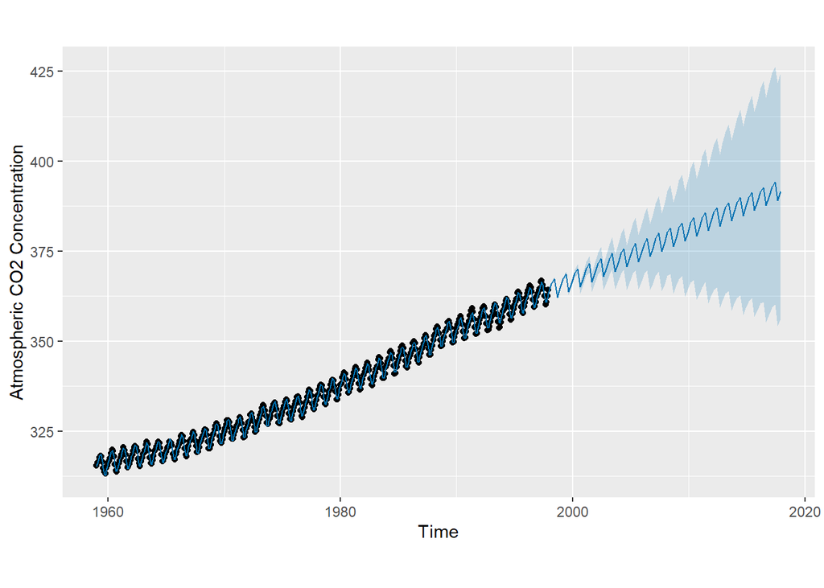

```r
# Creating a future data frame:
CO2_future_dataframe = prophet::make_future_dataframe(prophet_model, periods=80, freq="quarter")

# Predicting future co2 concentration:
CO2_Concentration_Forecast= predict(prophet_model, CO2_future_dataframe)
plot(prophet_model, CO2_Concentration_Forecast, ylabel = "Atmospheric CO2 Concentration", xlabel = "Time")
```

The graph above shows a 20 year forecast of Atmospheric CO2 Concentration produced by the Mauna Loa Volcano. Like before black dots on the graph represent the observed historic information of Atmospheric CO2 Concentration between 1959 and 1997. The thin blue line represents the fitted line between the observations, and represents the seasonal pattern that Atmospheric CO2 Concentration posses.

Unlike in the 3 year forecast, it is clear that `prophet` is having some difficulties producing an accurate forecast due to the variability represented by the light blue shaded region. This is most likely due to `co2` time series having a small pool of observations, so its difficult for `prophet` to predict future data using historic observations.

By inspecting `CO2_Concentration_Forecast$yaht` we will obtain the estimated values that `prophet` has produced. The first entry represents Atmospheric CO2 Concentration on 01/01/1959 which has remained the same as before, 315.2762. As expected the last value for Atmospheric CO2 Concentration predicted by `prophet` has increase over time. On 2017/12/01 `prophet` has predicted that Atmospheric CO2 Concentration will be 391.6251.